© Bản quyền thuộc về Quantopian Inc.  
© Bản quyền sửa đổi thuộc về AI Cafe¹  
Giấy phép [Creative Commons Attribution 4.0](https://creativecommons.org/licenses/by/4.0/legalcode).  
[Khuyến cáo](https://aicafe.one/khuyen-cao/)

# Chiến lược long-short equity

By Delaney Granizo-Mackenzie

Edited by AI Cafe¹

Chiến lược long-short equity đề cập đến việc chiến lược này vừa có vị thế mua (long) vừa có vị thế bán (short) trên thị trường cổ phiếu. Đây là một phát biểu khá tổng quát, nhưng theo thời gian đã trở thành một gia đình chiến lược cụ thể. Những chiến lược này xếp hạng tất cả các cổ phiếu trên thị trường bằng cách sử dụng một mô hình nào đó. Chiến lược sau đó sẽ mua (long) các cổ phiếu hàng đầu trong bảng xếp hạng và bán (short) các cổ phiếu ở vị trí thấp nhất, đồng thời duy trì khối lượng tiền bằng nhau giữa các vị thế long và short. Điều này có lợi thế là có độ tin cậy thống kê cao, vì bằng cách xếp hạng cổ phiếu và tham gia vào hàng trăm hoặc hàng ngàn vị thế, bạn đang thực hiện nhiều lần cược vào mô hình xếp hạng của mình thay vì chỉ một vài lần cược rủi ro. Bạn cũng đang đặt cược hoàn toàn vào chất lượng của hệ thống xếp hạng của mình, vì các vị thế long và short có khối lượng tiền bằng nhau đảm bảo rằng chiến lược sẽ duy trì trạng thái trung lập với thị trường (miễn dịch với các biến động của thị trường).

## Hệ thống Xếp hạng

Hệ thống xếp hạng là bất kỳ mô hình nào có thể gán cho mỗi cổ phiếu một số, trong đó số cao hơn có nghĩa là tốt hơn hoặc tệ hơn. Các ví dụ có thể bao gồm các yếu tố giá trị, chỉ báo kỹ thuật, mô hình định giá, hoặc sự kết hợp của tất cả những điều trên. Các hệ thống xếp hạng là "nước sốt bí mật" của bất kỳ chiến lược long-short equity nào, vì vậy việc phát triển chúng không phải là điều đơn giản.

## Đặt Cược Vào Kế Hoạch Xếp Hạng

Khi chúng ta đã xác định một kế hoạch xếp hạng, chúng ta muốn có thể thu lợi từ nó. Chúng ta làm điều này bằng cách đầu tư một số tiền bằng nhau vào các cổ phiếu đứng đầu xếp hạng và bán khống các cổ phiếu đứng cuối. Điều này đảm bảo rằng chiến lược sẽ kiếm tiền tỷ lệ thuận với chất lượng của kế hoạch xếp hạng và sẽ không phụ thuộc vào thị trường.

## Giỏ Long và Short

Nếu bạn đang xếp hạng $m$ cổ phiếu, có $d$ đồng để đầu tư, và tổng số vị trí mục tiêu bạn muốn giữ là $2n$, thì các giỏ dài và ngắn sẽ được tạo ra như sau. Đối với mỗi cổ phiếu ở vị trí $1, \dots, n$ trong bảng xếp hạng, bán $\frac{1}{2n} * d$ đồng của cổ phiếu đó. Đối với mỗi cổ phiếu ở vị trí $m - n, \dots, m$ trong bảng xếp hạng, mua $\frac{1}{2n} * d$ đồng của cổ phiếu đó.

## Trở Ngại Do Giá Cả

Bởi vì giá cổ phiếu sẽ không luôn chia đều $\frac{1}{2n} * d$, và cổ phiếu phải được mua với số lượng nguyên, sẽ có một số độ không chính xác và thuật toán nên cố gắng gần đạt đến con số này nhất có thể. Hầu hết các thuật toán sẽ có quyền truy cập vào một số đòn bẩy trong quá trình thực hiện, vì vậy việc mua hơi nhiều hơn $\frac{1}{2n} * d$ đồng cho mỗi cổ phiếu là điều chấp nhận được. Tuy nhiên, điều này sẽ gây ra một số trở ngại với số vốn thấp. Đối với một chiến lược có $d = 100000$, và $n = 500$, chúng ta thấy rằng $$\frac{1}{2n} * d = \frac{1}{1000} * 100000 = 100$$ Điều này sẽ gây ra vấn đề lớn cho các cổ phiếu đắt tiền và khiến thuật toán bị sử dụng đòn bẩy quá mức. Điều này có thể được khắc phục bằng cách giao dịch ít cổ phiếu hơn hoặc tăng vốn, $d$. May mắn thay, các chiến lược cổ phiếu Long-Short thường có dung lượng rất cao, vì vậy về hầu hết các mục đích không có giới hạn cho số tiền mà một người có thể đầu tư.

## Lợi Nhuận Đến Từ Sự Chênh Lệch Xếp Hạng

Lợi nhuận của một chiến lược chứng khoán dài-ngắn phụ thuộc vào việc sự xếp hạng phân tán tốt các lợi nhuận cao và thấp như thế nào. Để hiểu rõ hơn về cách hoạt động này, hãy xem xét ví dụ giả định sau đây.

```python
import numpy as np
import pandas as pd
import matplotlib.pyplot as plt
```

```python
# We'll generate a random factor
current_factor_values = np.random.normal(0, 1, 10000)
equity_names = ['Equity ' + str(x) for x in range(10000)]
# Put it into a dataframe
factor_data = pd.Series(current_factor_values, index = equity_names)
factor_data = pd.DataFrame(factor_data, columns=['Factor Value'])
# Take a look at the dataframe
factor_data.head(10)
```

|  | Factor Value |
| --- | --- |
| Equity 0 | 1.253263 |
| Equity 1 | -0.580093 |
| Equity 2 | -0.108888 |
| Equity 3 | 0.506108 |
| Equity 4 | -1.492940 |
| Equity 5 | -0.863709 |
| Equity 6 | -0.356223 |
| Equity 7 | -1.199196 |
| Equity 8 | -1.187480 |
| Equity 9 | -1.593593 |

```python
# Now let's say our future returns are dependent on our factor values
future_returns = current_factor_values + np.random.normal(0, 1, 10000)

returns_data = pd.Series(future_returns, index=equity_names)
returns_data = pd.DataFrame(returns_data, columns=['Returns'])
# Put both the factor values and returns into one dataframe
data = returns_data.join(factor_data)
# Take a look
data.head(10)
```

|  | Returns | Factor Value |
| --- | --- | --- |
| Equity 0 | 3.375804 | 1.253263 |
| Equity 1 | 0.241810 | -0.580093 |
| Equity 2 | -1.104191 | -0.108888 |
| Equity 3 | 0.585656 | 0.506108 |
| Equity 4 | -1.053634 | -1.492940 |
| Equity 5 | 1.594298 | -0.863709 |
| Equity 6 | 1.340790 | -0.356223 |
| Equity 7 | -0.769068 | -1.199196 |
| Equity 8 | -1.640397 | -1.187480 |
| Equity 9 | -1.268676 | -1.593593 |

Bây giờ khi chúng ta đã có giá trị yếu tố và lợi nhuận, chúng ta có thể xem điều gì sẽ xảy ra nếu chúng ta xếp hạng các cổ phiếu của mình dựa trên giá trị yếu tố, và sau đó thực hiện các vị thế mua và bán khống.

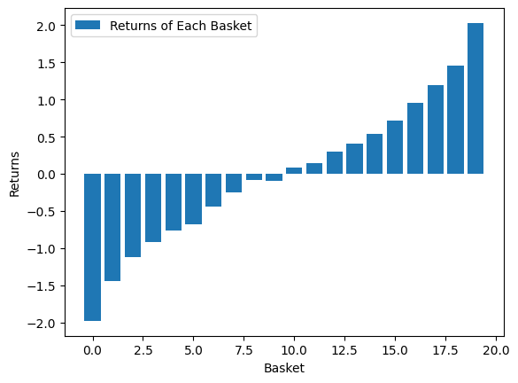

```python
# Rank the equities
ranked_data = data.sort_values('Factor Value')

# Compute the returns of each basket
# Baskets of size 500, so we create an empty array of shape (10000/500)
number_of_baskets = 10000//500
basket_returns = np.zeros(number_of_baskets)

for i in range(number_of_baskets):
    start = i * 500
    end = i * 500 + 500
    basket_returns[i] = ranked_data[start:end]['Returns'].mean()

# Plot the returns of each basket
plt.bar(range(number_of_baskets), basket_returns)
plt.ylabel('Returns')
plt.xlabel('Basket')
plt.legend(['Returns of Each Basket']);
```

Hãy tính toán lợi nhuận nếu chúng ta mua Long giỏ hàng trên và bán khống giỏ hàng dưới.

```python
basket_returns[number_of_baskets-1] - basket_returns[0]
```

```
np.float64(4.009224704447246)
```

## Tính Trung Lập Thị Trường Đã Được Xây Dựng Sẵn

Điều tuyệt vời về việc kiếm tiền dựa trên chênh lệch xếp hạng là nó không bị ảnh hưởng bởi những gì thị trường làm.

```python
# We'll generate a random factor
current_factor_values = np.random.normal(0, 1, 10000)
equity_names = ['Equity ' + str(x) for x in range(10000)]
# Put it into a dataframe
factor_data = pd.Series(current_factor_values, index = equity_names)
factor_data = pd.DataFrame(factor_data, columns=['Factor Value'])

# Now let's say our future returns are dependent on our factor values
future_returns = -10 + current_factor_values + np.random.normal(0, 1, 10000)

returns_data = pd.Series(future_returns, index=equity_names)
returns_data = pd.DataFrame(returns_data, columns=['Returns'])
# Put both the factor values and returns into one dataframe
data = returns_data.join(factor_data)

# Rank the equities
ranked_data = data.sort_values('Factor Value')

# Compute the returns of each basket
# Baskets of size 500, so we create an empty array of shape (10000/500
number_of_baskets = 10000//500
basket_returns = np.zeros(number_of_baskets)

for i in range(number_of_baskets):
    start = i * 500
    end = i * 500 + 500
    basket_returns[i] = ranked_data[start:end]['Returns'].mean()

basket_returns[number_of_baskets-1] - basket_returns[0]
```

```
np.float64(4.1679695162236365)
```

## Lựa Chọn và Đánh Giá Một Hệ Thống Xếp Hạng

Hệ thống xếp hạng là nơi mà chiến lược đầu tư dài-ngắn có được lợi thế, và là thành phần quan trọng nhất. Việc chọn một hệ thống xếp hạng tốt là toàn bộ bí quyết, và không có câu trả lời nào dễ dàng. Một điểm khởi đầu tốt là chọn các kỹ thuật đã biết có sẵn, và xem liệu bạn có thể điều chỉnh chúng một cách nhẹ nhàng để tăng lợi nhuận hay không. Thông tin thêm về việc xây dựng hệ thống xếp hạng có thể được tìm thấy trong các bài giảng được liệt kê dưới đây.

Trong quá trình nghiên cứu hệ thống xếp hạng của bạn, điều quan trọng là xác định xem hệ thống xếp hạng của bạn có thực sự dự đoán được lợi nhuận trong tương lai hay không. Điều này có thể được thực hiện bằng cách sử dụng hệ số tương quan thứ bậc Spearman.

Thông tin về việc xây dựng và đánh giá các hệ thống xếp hạng có sẵn trong các bài giảng sau:

- Lựa Chọn Tập Vũ Trụ
- Hệ Số Tương Quan Thứ Bậc Spearman
- Phân Tích Yếu Tố với Alphalens

## Long-Short là một Chiến lược Module

Để thực hiện một chiến lược đầu tư Long-Short, bạn chỉ cần xác định hệ thống xếp hạng. Mọi thứ sau đó đều mang tính cơ học. Khi bạn có một chiến lược đầu tư Long-Short, bạn có thể thay đổi các hệ thống xếp hạng khác nhau mà không cần thay đổi mọi thứ khác. Đây là một cách rất tiện lợi để nhanh chóng thử nghiệm các ý tưởng mà bạn có mà không cần lo lắng về việc điều chỉnh mã mỗi lần.

Các hệ thống xếp hạng có thể đến từ hầu như bất kỳ mô hình nào. Nó không nhất thiết phải là một mô hình yếu tố dựa trên giá trị, mà có thể là một kỹ thuật học máy dự đoán lợi nhuận trước một tháng và xếp hạng dựa trên điều đó.

## Tần suất Cân bằng lại

Mỗi hệ thống xếp hạng sẽ dự đoán lợi nhuận trong một khoảng thời gian hơi khác nhau. Một mô hình hồi quy dựa trên giá có thể dự đoán trong vài ngày, trong khi một mô hình yếu tố dựa trên giá trị có thể dự đoán trong nhiều tháng. Quan trọng là xác định khoảng thời gian mà mô hình của bạn nên dự đoán, và xác minh thống kê điều đó trước khi thực hiện chiến lược của bạn. Bạn không muốn bị quá khớp bằng cách cố gắng tối ưu hóa tần suất cân bằng lại, vì bạn sẽ chắc chắn tìm thấy một cái ngẫu nhiên tốt hơn những cái khác, nhưng không cần thiết bởi bất kỳ điều gì trong mô hình của bạn.

Khi bạn đã xác định được khoảng thời gian mà hệ thống xếp hạng của bạn có tính dự đoán, hãy cố gắng cân bằng lại vào khoảng tần suất đó để tận dụng tối đa các mô hình của bạn.

## Chi Phí Giao Dịch

Việc giao dịch nhiều cổ phiếu sẽ dẫn đến chi phí giao dịch cao. Giả sử bạn muốn mua 1000 cổ phiếu, bạn sẽ phải chịu hàng triệu đồng chi phí cho mỗi lần tái cân bằng. Vốn đầu tư của bạn phải đủ lớn để chi phí giao dịch chỉ là một tỷ lệ nhỏ trong số lợi nhuận mà chiến lược của bạn tạo ra. Giả sử bạn đang quản lý 1 tỷ đồng và kiếm được 1% mỗi tháng, thì 10 triệu đồng phí giao dịch mỗi tháng sẽ chiếm hết toàn bộ lợi nhuận của bạn. Bạn sẽ cần phải quản lý chiến lược trên hàng trăm tỷ đồng để có lợi nhuận từ 1000 cổ phiếu.

Sức chứa tối thiểu khá cao như vậy, và phụ thuộc chủ yếu vào số lượng cổ phiếu giao dịch. Tuy nhiên, sức chứa tối đa cũng cực kỳ cao, với các chiến lược cổ phiếu Long-Short có khả năng giao dịch hàng trăm tỷ đồng mà không mất đi lợi thế của chúng. Điều này đúng vì chiến lược tái cân bằng tương đối không thường xuyên, và tổng giá trị được chia cho số lượng cổ phiếu giao dịch. Vì vậy, nếu bạn quay vòng toàn bộ danh mục đầu tư 100 tỷ đồng mỗi tháng trong khi quản lý 1000 cổ phiếu, bạn chỉ đang giao dịch 100 triệu đồng khối lượng mỗi tháng qua mỗi cổ phiếu, điều này không đủ để trở thành một phần thị trường đáng kể cho hầu hết các chứng khoán.

*Lưu ý: Tài liệu này mang tính chất chia sẻ kiến thức khoa học dữ liệu. Các mã chứng khoán xuất hiện trong tài liệu chỉ mang tính chất minh hoạ, không khuyến nghị đầu tư. Chúng tôi không chịu trách nhiệm trước mọi rủi ro nào do sử dụng tài liệu này.*